# PA1_template.Rmd

keadz2305

March 6, 2016

### Loading and preprocessing the data

```r
data <- read.csv("./activity.csv")
data$date <- as.Date(data$date, "%Y-%m-%d")
```

### What is mean total number of steps taken per day?

#### Calculate the total number of steps taken per day

```r
aggdata = aggregate(data$steps~data$date,FUN=sum)
```

#### Make a histogram of the total number of steps taken each day

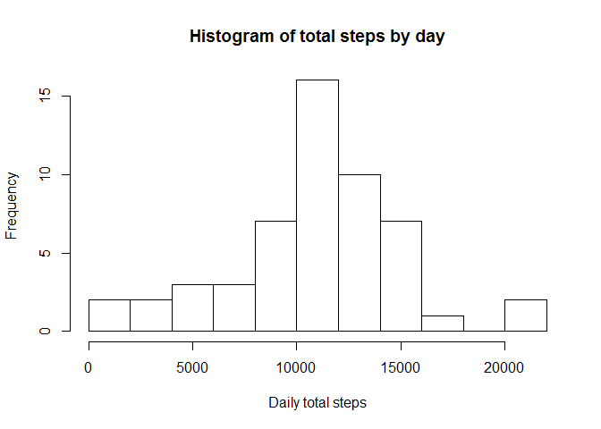

#### Calculate and report the mean and median of the total number of steps taken per day

```r
daymeansteps <- as.integer(mean(aggdata$`data$steps`))
daymedsteps <- median(aggdata$`data$steps`)
```

The mean total number of steps taken per day is:10766

The median total number of steps taken per day is:10765

### What is the average daily activity pattern?

#### Make a time series plot (i.e. type = “l”) of the 5-minute interval (x-axis) and the average number of steps taken, averaged across all days (y-axis)

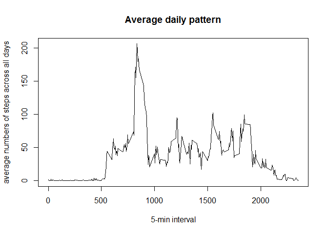

#### Which 5-minute interval, on average across all the days in the dataset, contains the maximum number of steps?

```r
timemaxint <- dataintmean[which.max(dataintmean$`data$steps`),]
maxtime <- timemaxint$`data$interval`
```

The maximum number of steps oocurs at 835.

### Imputing missing values

#### Calculate and report the total number of missing values in the dataset (i.e. the total number of rows with NAs)

```r
stepsNA <- sum(is.na(data$steps))
```

The total numer of missing values in the dataset is 2304.

#### Devise a strategy for filling in all of the missing values in the dataset. The strategy does not need to be sophisticated. For example, you could use the mean/median for that day, or the mean for that 5-minute interval, etc.

Use the mean steps for the 5-minute interval to replace missing steps values at corresponding time intervals

1. create a vector (NAindex) with the index values of the NAs in the dataset
2. create a vector (NAtime) of the corresponding time interval of the NAs
3. create a vector (NAsteps) of NAs same length as NAindex and NAtime
4. create a data frame with the 3 vectors
5. perform a to match each time interval with a corresponding means steps for that time interval
6. assign the means steps back to the datasets at the corresponding index position

#### Create a new dataset that is equal to the original dataset but with the missing data filled in.

```r
NAindex <- which(is.na(data$steps))
NAtime <- data$interval[NAindex]
NAsteps <- dataintmean$`data$steps`[dataintmean$`data$interval`== NAtime[(seq(1,2304))]]
NAdata <- data.frame(cbind(NAindex,NAtime,NAsteps))
tmpNA <- merge(dataintmean,NAdata,by.x="data$interval",by.y="NAtime")
newNA <- tmpNA[,1:3]
newNA2 <- newNA[order(newNA$NAindex),]
newdata <- data
newdata$steps[NAindex] <- newNA2$`data$steps`[seq(1,2304)]
```

```r
aggdatanew = aggregate(newdata$steps~newdata$date,FUN=sum)
```

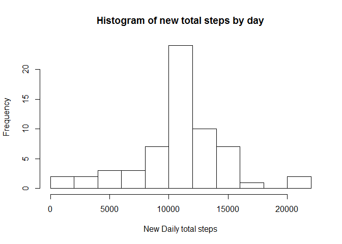

```r
newdaymeansteps <- as.integer(mean(aggdatanew$`newdata$steps`))
newdaymedsteps <- median(aggdatanew$`newdata$steps`)
```

The new mean total number of steps taken per day is:10766

### Are there differences in activity patterns between weekdays and weekends?

#### Create a new factor variable in the dataset with two levels - “weekday” and “weekend” indicating whether a given date is a weekday or weekend day.

```r
newdata$day <- weekdays(as.Date(newdata$date))
dow <- data.frame(day=c("Monday","Tuesday","Wednesday","Thursday","Friday","Saturday","Sunday"),wkday_wkend=c("weekday","weekday","weekday","weekday","weekday","weekend","weekend"))
tmpdow <- merge(newdata,dow,by.x="day",by.y="day")
newdow <- tmpdow[order(tmpdow$date),]
newdata2 <- newdow[,-1]
```

#### Make a panel plot containing a time series plot (i.e. type = “l”) of the 5-minute interval (x-axis) and the average number of steps taken, averaged across all weekday days or weekend days (y-axis).

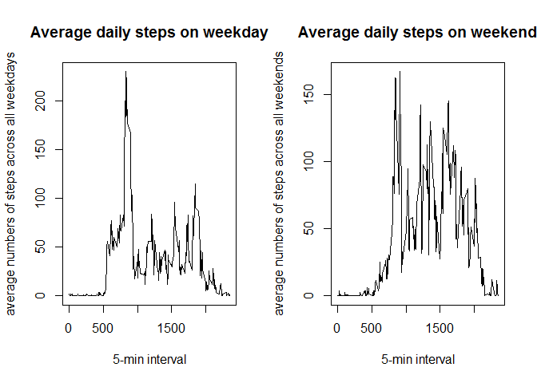